# BayessianNet_2

## Construcción de las redes

- Red desarrollada en base al estudio de la independencia:

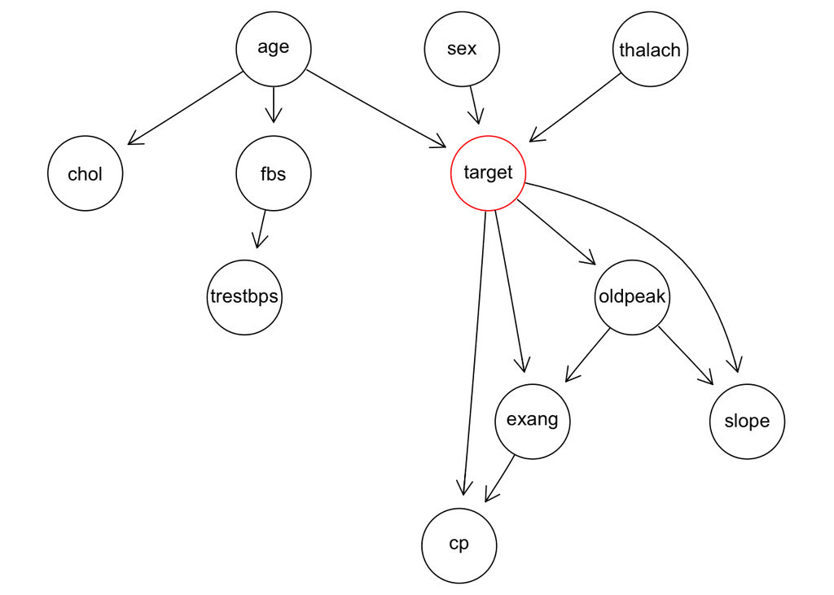

```r
description.1 <- paste('[age][sex][thalach]',
                       '[chol|age]',
                       '[fbs|age]',
                       '[trestbps|fbs]',
                       '[target|age:thalach:sex]',
                       '[cp|target:exang]',
                       '[exang|target:oldpeak]',
                       '[oldpeak|target]',
                       '[slope|oldpeak:target]', sep = '')
bl.heart.1 <- model2network(description.1)
plot(bl.heart.1, highlight = list(nodes = "target"))
```

NOTA: La taquicardia puede considerarse a la vez una causa y una consecuencia. Causa en el sentido de que un incremento en la frecuencia cardiaca puede provocar un ataque cardiaco y consecuencia en el sentido de que cuando se da daño cardiaco puede disminuir la frecuencia cardiaca dada la ineficiencia del corazón originada por la lesión. **En la red será considerado una causa**.

- Red desarrollada en base a un algoritmo completo (Silander-Myllymaki) que usa como *score* el *Bayesian Information Criterium*.

Se puede ver que con este método algunas flechas no son coherentes, por lo que se seguirá esta estructura cambiando la dirección de algunas flechas

```r
library(bnstruct)
```

```r
dataset <- BNDataset(data = data,
                     discreteness = rep(TRUE,length(names(data))),
                     variables = names(data),
                     node.sizes = c(2, 2, 2, 2, 3, 2, 2, 2, 3, 3, 2))
```

```r
imp.dataset <- impute(dataset)
```

```r
bl.heart.pre <- learn.network(imp.dataset,
                              algo = "sm",
                              scoring.func = "BIC",
                              use.imputed.data = TRUE)
```

```
## node  1
## node  2
## node  3
## node  4
## node  5
## node  6
## node  7
## node  8
## node  9
## node  10
## node  11
```

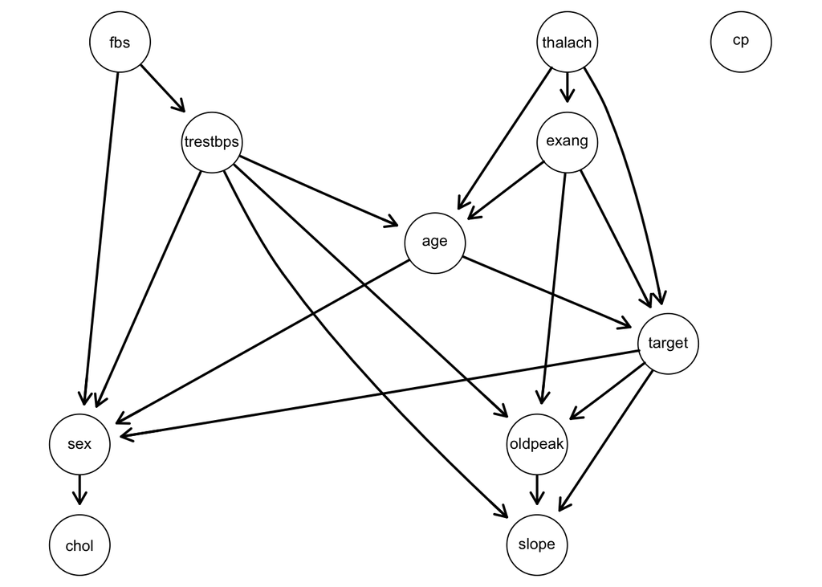

```r
plot(bl.heart.pre)
```

Se elimino la relacción entre sexo y edad y se redigieron las flechas.

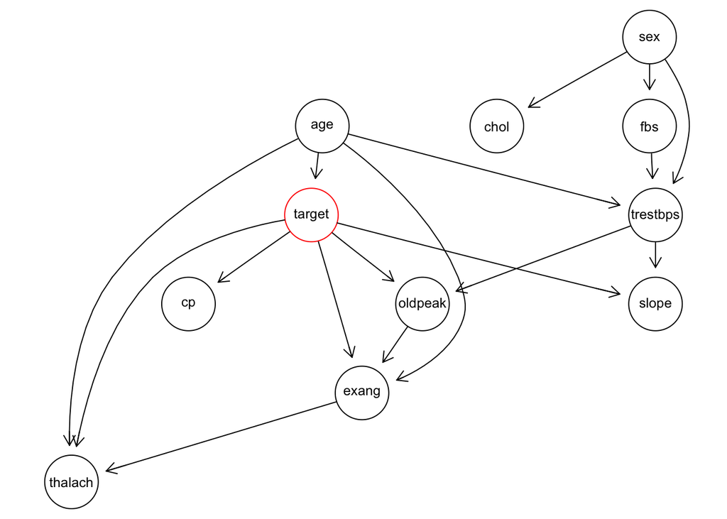

```r
description.2 <- paste('[fbs|sex]',
                       '[chol|sex]',
                       '[sex]',
                       '[trestbps|fbs:sex:age]',
                       '[age]',
                       '[thalach|age:target:exang]',
                       '[exang|age:target:oldpeak]',
                       '[oldpeak|target:trestbps]',
                       '[cp|target]',
                       '[slope|trestbps:target]',
                       '[target|age]',
                        sep = '')

bl.heart.2 <- model2network(description.2)
plot(bl.heart.2, highlight = list(nodes = "target"))
```